# mtcars Regression Analysis

here,R is treating some of the column as numeric instead of that they should be treated as factor, And then we will find correlation of mpg with other continuous variable.

```r
mtcars <- tibble(mtcars)
mtcars$vs <- as.factor(mtcars$vs)
mtcars$am <- as.factor(mtcars$am)
mtcars$gear <- as.factor(mtcars$gear)
mtcars$carb <- as.factor(mtcars$carb)
mtcars$cyl <- as.factor(mtcars$cyl)
head(mtcars)
```

```
## # A tibble: 6 x 11
##     mpg cyl    disp    hp  drat    wt  qsec vs    am    gear  carb
##   <dbl> <fct> <dbl> <dbl> <dbl> <dbl> <dbl> <fct> <fct> <fct> <fct>
## 1  21   6       160   110  3.9   2.62  16.5 0     1     4     4
## 2  21   6       160   110  3.9   2.88  17.0 0     1     4     4
## 3  22.8 4       108    93  3.85  2.32  18.6 1     1     4     1
## 4  21.4 6       258   110  3.08  3.22  19.4 1     0     3     1
## 5  18.7 8       360   175  3.15  3.44  17.0 0     0     3     2
## 6  18.1 6       225   105  2.76  3.46  20.2 1     0     3     1
```

```r
cont_mtcars <- mtcars %>% select(mpg,disp,hp,drat,wt,qsec)
cor(cont_mtcars)
```

```
##             mpg       disp         hp        drat         wt        qsec
## mpg   1.0000000 -0.8475514 -0.7761684  0.68117191 -0.8676594  0.41868403
## disp -0.8475514  1.0000000  0.7909486 -0.71021393  0.8879799 -0.43369788
## hp   -0.7761684  0.7909486  1.0000000 -0.44875912  0.6587479 -0.70822339
## drat  0.6811719 -0.7102139 -0.4487591  1.00000000 -0.7124406  0.09120476
## wt   -0.8676594  0.8879799  0.6587479 -0.71244065  1.0000000 -0.17471588
## qsec  0.4186840 -0.4336979 -0.7082234  0.09120476 -0.1747159  1.00000000
```

Here, we see that mpg and qsec are moderately correlated so we are including in our study.  
Now we will fit the model(multiple linear regression) model with all other continuous variable and with including only one categorical variable *am*(Transmission (0 = automatic, 1 = manual)).

```r
new_mtcars <- mtcars %>% select(mpg,disp,hp,drat,wt,qsec,am)
fit1 <- lm(mpg~.,data = new_mtcars)
summary(fit1)
```

```
##
## Call:
## lm(formula = mpg ~ ., data = new_mtcars)
##
## Residuals:
##     Min      1Q  Median      3Q     Max
## -3.2669 -1.6148 -0.2585  1.1220  4.5564
##
## Coefficients:
##             Estimate Std. Error t value Pr(>|t|)
## (Intercept) 10.71062   10.97539   0.976  0.33848
## disp         0.01310    0.01098   1.193  0.24405
## hp          -0.02180    0.01465  -1.488  0.14938
## drat         1.02065    1.36748   0.746  0.46240
## wt          -4.04454    1.20558  -3.355  0.00254 **
## qsec         0.99073    0.48002   2.064  0.04955 *
## am1          2.98469    1.63382   1.827  0.07969 .
## ---
## Signif. codes:  0 '***' 0.001 '**' 0.01 '*' 0.05 '.' 0.1 ' ' 1
##
## Residual standard error: 2.45 on 25 degrees of freedom
## Multiple R-squared:  0.8667, Adjusted R-squared:  0.8347
## F-statistic: 27.09 on 6 and 25 DF,  p-value: 8.637e-10
```

Following are residual diagnostic plot:

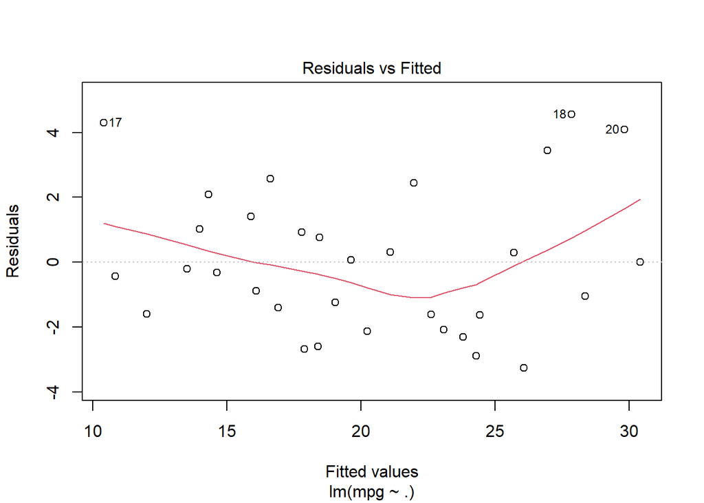

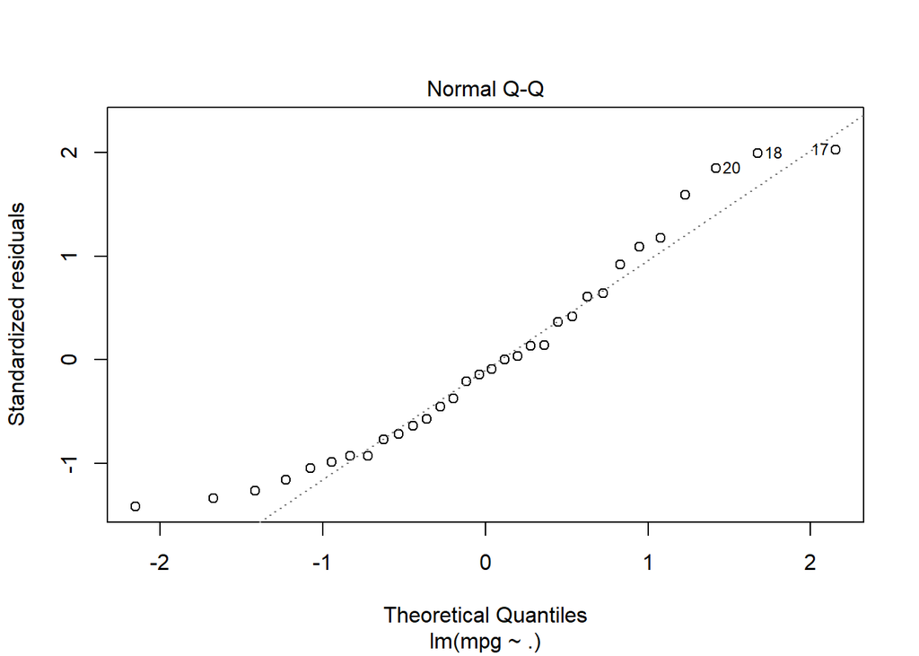

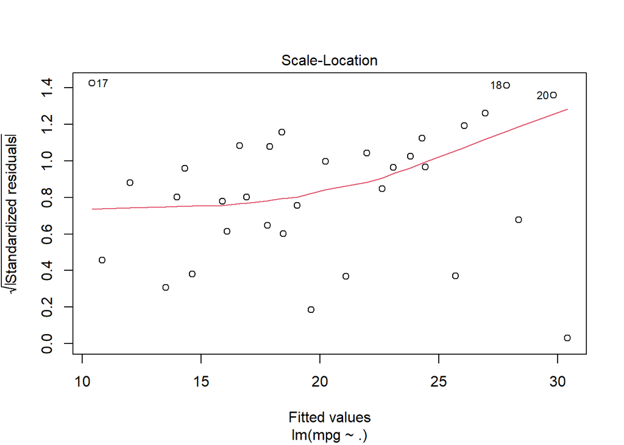

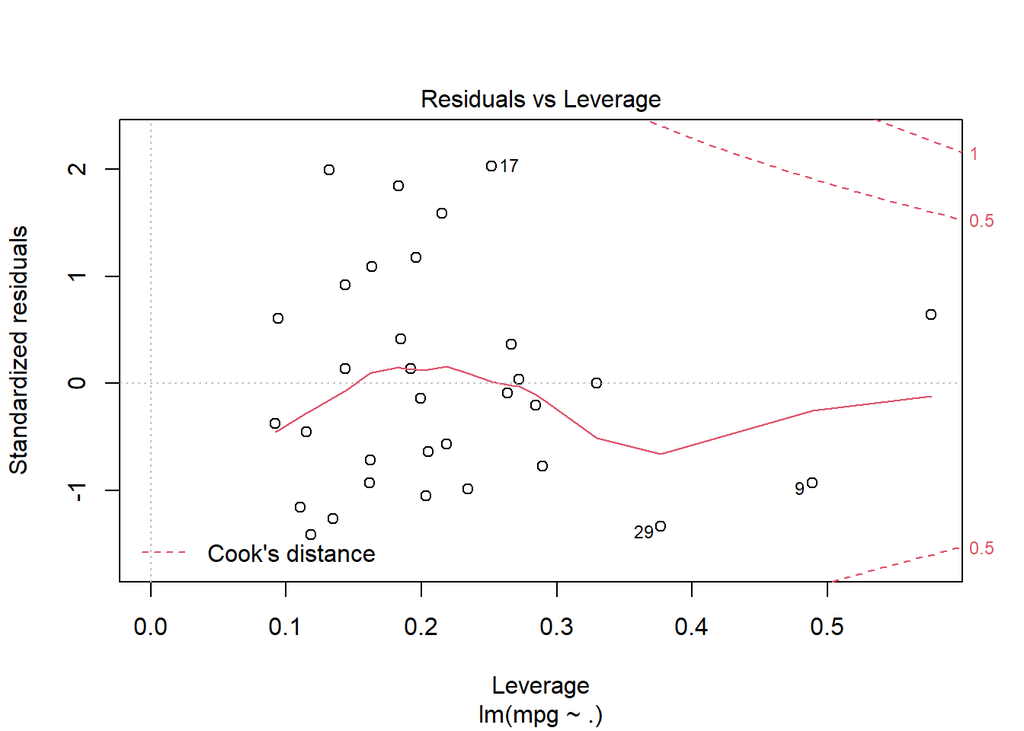

```r
plot(fit1)
```

From Residual Vs Fitted plot we see that, as time goes, spread of data is somewhat seems to be increasing.. which tells that residuals are increasing function of target, i.e assumption of constant variance is violated here.Which can be made stabilized using log transformation on output/target variable before fitting.  
Quantile plot of residuals is showing our residuals are normally distributed.Plot can we made more interpretative as residuals are following Gaussian(Normal) distribution if we use log transformation to target at starting of model building.  
Residual Vs leverage plot shows that there are no outlier in our data.